# Report - Data Mining I

Fabio Teixeira, Miguel Ferreira, Vanessa Silva

20 de Dezembro de 2016

This report follows the predictive analysis of a data set on crime events in Houston, Texas, USA.

This analysis is made by three fundamental tasks: data import and clean-up, data exploratory analysis and predictive modeling. The first task is to import, in an appropriate format R, the data, in order to simplify the analysis thereof, and to perform any data clean-up and/or pre-processing steps, if necessary. The second, in presenting summaries, questions and visualization of the data in ways that will be useful to the police. And in the third task, a prediction task is defined, where a model and its justification are presented, which can help the police answer the question: “What will be the number of events/offenses in police beat X for the period of the day Y?”.

**The Problem**

Obtain a model that helps the police to distribute its resources through the different areas of the city (policy beats).

We will assume that the goal of the policy department is to allocate the resources based on the number of estimated events (of any type) for a certain area, i.e., the goal is to accurately estimate the number of events (offenses) that are going to occur on a certain area.

The police makes personel allocation decisions 3 times per day: (i) one decision for the morning period (8:00<= t < 12:00); (ii) one for the afternoon (12:00 <= t < 19:00); and the last decision for the night period (19:00 <= t < 8:00). These decisions are made for each week day and for each police beat.

**The Data**

The provided spreadsheet contains information on crime events on Houston, Texas, USA. Each row contains several information on the event.

# First Task

## Data import and clean-up

### Setting the working directory

Download the file “**crime.xls**” to the directory where you are going to work. Alternatively, if you want to change the current directory, do:

```r
setwd(dir)
```

And to view the current directory:

```r
getwd()
```

```
## [1] "C:/Users/vanes/Documents/Universidade/Data Mining I/Trabalho/DMI-Part1"
```

### Import the data

**Note:** If you do not have Perl installed on Windows, download it [here](http://www.activestate.com/activeperl/downloads). In other Operative Systems, like Linux Ubuntu, it’s usual to have Perl installed.

```r
#Install the necessary packages
install.packages("gdata")
install.packages("lubridate")
install.packages("xts")
install.packages("dplyr")
install.packages("DMwR")
install.packages("e1071")
install.packages("earth")
install.packages("rpart.plot")
install.packages("performanceEstimation")
```

**Note:** If an error occurred, in Ubuntu, in the installation of the package “earth”, run the following command in the Terminal:

```bash
sudo apt-get install liblapack-dev
```

And then, try again:

```r
install.packages("earth")
```

```r
#Load the packages
library(gdata)
library(lubridate)
library(xts)
library(dplyr)
library(stringr)
library(DMwR)
library(class)
library(nnet)
library(e1071)
library(earth)
library(performanceEstimation)
library(DMwR)
library(rpart.plot)

#The path to "perl.exe"
perldir <- Sys.which("perl")

#Loading the file "crime.xls"
fc <- "crime.xls"
dat <- read.xls(fc, sheet = 1, header = TRUE, verbose=FALSE, perl=perldir, na.strings = "UNK")

#Dimension of data
dim(dat)

#Names of data
names(dat)

#Structure of data
str(dat)

dat$BlockRange <- as.character(dat$BlockRange)
dat$StreetName <- as.character(dat$StreetName)
dat$Type <- as.character(dat$Type)
dat$Suffix <- as.character(dat$Suffix)
```

### Data clean-up and/or pre-processing steps necessary

The offense types found on the data set are:

```r
unique(dat$Offense.Type)
```

```
## [1] Auto Theft         Theft              Burglary
## [4] Robbery            Aggravated Assault Rape
## [7] Murder             1
## 8 Levels: 1 Aggravated Assault Auto Theft Burglary Murder ... Theft
```

We identified an instance where the `Offense.Type` column does not have a valid value. However, it is a registered crime that quite possibly happened, and although it may not help predicting which crimes may occur, it will surely help predicting how many crimes per beat will occur.

```r
dat[dat$Offense.Type == 1,]
```

```
##            Date Hour Offense.Type  Beat Premise BlockRange StreetName Type
## 1023 2015-01-01    0            1 12D10            800-899   EASTLAKE   ST
##      Suffix X..offenses
## 1023      -           1
```

All dates have a valid format:

```r
dat[!grep("^[0-9]{4}-[0-9]{2}-[0-9]{2}$", dat$Date),]
```

```
##  [1] Date         Hour         Offense.Type Beat         Premise
##  [6] BlockRange   StreetName   Type         Suffix       X..offenses
## <0 rows> (or 0-length row.names)
```

All hours have a valid format:

```r
dat[dat$Hour < 0 | dat$Hour > 23,]
```

```
##  [1] Date         Hour         Offense.Type Beat         Premise
##  [6] BlockRange   StreetName   Type         Suffix       X..offenses
## <0 rows> (or 0-length row.names)
```

```r
dat[!grep("^[0-9]{2}$", dat$Hour),]
```

```
##  [1] Date         Hour         Offense.Type Beat         Premise
##  [6] BlockRange   StreetName   Type         Suffix       X..offenses
## <0 rows> (or 0-length row.names)
```

Some anomalies (unknown values) were found on the `Beat` column:

```r
unique(dat$Beat)
```

```
##   [1] 10H10 10H20 10H30 10H40 10H50 10H60 10H70 10H80 11H10 11H20 11H30
##  [12] 11H40 11H50 12D10 12D20 12D30 12D40 12D50 12D60 12D70 13D10 13D20
##  [23] 13D30 13D40 14D10 14D20 14D30 14D40 14D50 15E10 15E20 15E30 15E40
##  [34] 16E10 16E20 16E30 16E40 17E10 17E20 17E30 17E40 18F10 18F20 18F30
##  [45] 18F40 18F50 18F60 19G10 19G20 19G30 19G40 19G50 1A10  1A20  1A30
##  [56] 1A40  1A50  20G10 20G20 20G30 20G40 20G50 20G60 20G70 20G80 21I10
##  [67] 21I20 21I30 21I50 21I60 23J50 24C10 24C20 24C30 24C40 24C50 24C60
##  [78] 2A10  2A20  2A30  2A40  2A50  2A60  3B10  3B30  3B40  3B50  4F10
##  [89] 4F20  4F30  5F10  5F20  5F30  5F40  6B10  6B20  6B30  6B40  6B50
## [100] 6B60  7C10  7C20  7C30  7C40  7C50  8C10  8C20  8C30  8C40  8C50
## [111] 8C60  9C10  9C20  9C30  9C40  <NA>
## 115 Levels: 10H10 10H20 10H30 10H40 10H50 10H60 10H70 10H80 11H10 ... 9C40
```

```r
nrow(dat[is.na(dat$Beat),])
```

```
## [1] 72
```

The `Beat` column is rather important since the purpose of the prediction model is given a beat and a time of the day, predict how many crimes will occur. Luckily, there are not many invalid `Beat` cells.

Some anomalies (unknown values) were found on the `BlockRange` column:

```r
nrow(dat[is.na(dat$BlockRange),])
```

```
## [1] 174
```

Some anomalies (worthless) were found on the `Type` column:

```r
unique(dat$Type)
```

```
##  [1] "ST"   "-"    "WAY"  "DR"   "FWY"  "BLVD" "AVE"  "RD"   "TRL"  "CT"
## [11] "CIR"  "LN"   "PKWY" "VIEW" "PL"   "BND"  "LP"   "HWY"  "RAMP" "BYP"
```

```r
nrow(dat[dat$Type == "-",])
```

```
## [1] 2402
```

Some anomalies (worthless) were found on the `Suffix` column:

```r
unique(dat$Suffix)
```

```
## [1] "-" "N" "S" "W" "E"
```

```r
nrow(dat[dat$Suffix == "-",])
```

```
## [1] 8766
```

All offenses were counted:

```r
unique(dat$X..offenses)
```

```
## [1] 1 2 4 3
```

For each anomaly detected we have 3 options:

- Remove lines containing invalid data.
- Substitute invalid cells by a central measure of the cell.
- Substitute invalid cells by an average over the k-nearest neighbours of its line on the data set.

Based on Hounton Police beat map, we can reconstruct manually the `Beat` cells using the street name and block range.

[figure not shown]

However, using Google Maps API and Data Science Toolkit providers for the package `ggmap` we were able to obtain GPS coordinates for the locations of each crime. This allows us to reconstruct the `Beat` column using the k-nearest neighbours of the coordinates column. In order to that, we built an RData file, named “**gps.RData**”, that you should download to the working directory.

```r
load("gps.RData")
incomplete <- is.na(dat$Beat)
tr <- gps[!incomplete,1:2]
ts <- gps[incomplete,1:2]
dat$Beat[incomplete] <- knn(tr, ts, dat$Beat[!incomplete], k = 3)
```

We proceed in the same way to reconstruct (solving the anomalies) the `Suffix` column.

```r
incomplete <- (dat$Suffix == "-")
tr <- gps[!incomplete,1:2]
ts <- gps[incomplete,1:2]
dat$Suffix[incomplete] <- is.character(knn(tr, ts, dat$Suffix[!incomplete], k = 3))
```

To solve of the anomalies in `BlockRange` column, we replaced the invalid cells for the central value.

```r
incomplete <- is.na(dat$BlockRange)
dat$BlockRange[incomplete] <- centralValue(dat$BlockRange)
```

We proceed in the same way to solve of the anomalies in `Type` column.

```r
incomplete <- (dat$Type == "-")
dat$Type[incomplete] <- centralValue(dat$Type[!incomplete])
```

# Second Task

## Data exploratory analysis

Data **summarization** and **visualization** in ways that will be useful to the police.

```r
##Arrange "dat" in a data frame
dat <- tbl_df(dat)

#View the data per hour
datxts <- xts(dat, ymd_h(paste(dat$Date,' ',dat$Hour)))

#Distribution of every numeric variable and frequency of every level of every categorical variables
summary(dat)
```

```
##          Date           Hour                   Offense.Type
##  2015-01-12: 389   Min.   : 0.00   Theft             :5670
##  2015-01-07: 370   1st Qu.: 9.00   Burglary          :1886
##  2015-01-20: 365   Median :14.00   Auto Theft        :1131
##  2015-01-14: 360   Mean   :13.15   Robbery           : 838
##  2015-01-02: 354   3rd Qu.:18.00   Aggravated Assault: 641
##  2015-01-26: 344   Max.   :23.00   Rape              :  62
##  (Other)   :8070                   (Other)           :  24
##       Beat                                     Premise
##  12D10  : 241   Residence or House                 :1483
##  6B60   : 231   Apartment Parking Lot              :1106
##  1A20   : 227   Apartment                          :1030
##  17E10  : 211   Road, Street, or Sidewalk          : 845
##  18F20  : 202   Restaurant or Cafeteria Parking Lot: 454
##  13D20  : 198   Driveway                           : 414
##  (Other):8942   (Other)                            :4920
##   BlockRange         StreetName            Type
##  Length:10252       Length:10252       Length:10252
##  Class :character   Class :character   Class :character
##  Mode  :character   Mode  :character   Mode  :character
##
##
##
##
##     Suffix           X..offenses
##  Length:10252       Min.   :1.000
##  Class :character   1st Qu.:1.000
##  Mode  :character   Median :1.000
##                     Mean   :1.016
##                     3rd Qu.:1.000
##                     Max.   :4.000
##
```

```r
#Split the data into 3 categories
i1 <- filter(dat, 8 <= dat$Hour, dat$Hour < 12)
i2 <- filter(dat, 12 <= dat$Hour, dat$Hour < 19)
i3 <- filter(dat, (19 <= dat$Hour & dat$Hour <= 23) | (0 <= dat$Hour & dat$Hour < 8))

#How many offenses are made per interval in each category
sum1 <- group_by(i1, Beat) %>% summarise(num=sum(X..offenses))
sum2 <- group_by(i2, Beat) %>% summarise(num=sum(X..offenses))
sum3 <- group_by(i3, Beat) %>% summarise(num=sum(X..offenses))

#How many offenses are made per offense type
sum4 <- group_by(dat, Offense.Type) %>% summarise(num=sum(X..offenses))

#How many offenses are made per offense type in each beat
sum5 <- group_by(dat, Offense.Type, Beat) %>% summarise(num=sum(X..offenses))

#Data summarization (most common values)
dat %>% summarise(avg.Off=mean(dat$X..offenses),
                  cen.OffTp=centralValue(dat$Offense.Type),
                  cen.StrNm=centralValue(dat$StreetName))
```

```
## # A tibble: 1 × 3
##    avg.Off cen.OffTp  cen.StrNm
##      <dbl>     <chr>      <chr>
## 1 1.016094     Theft WESTHEIMER
```

Frequency of offenses in the interest intervals:

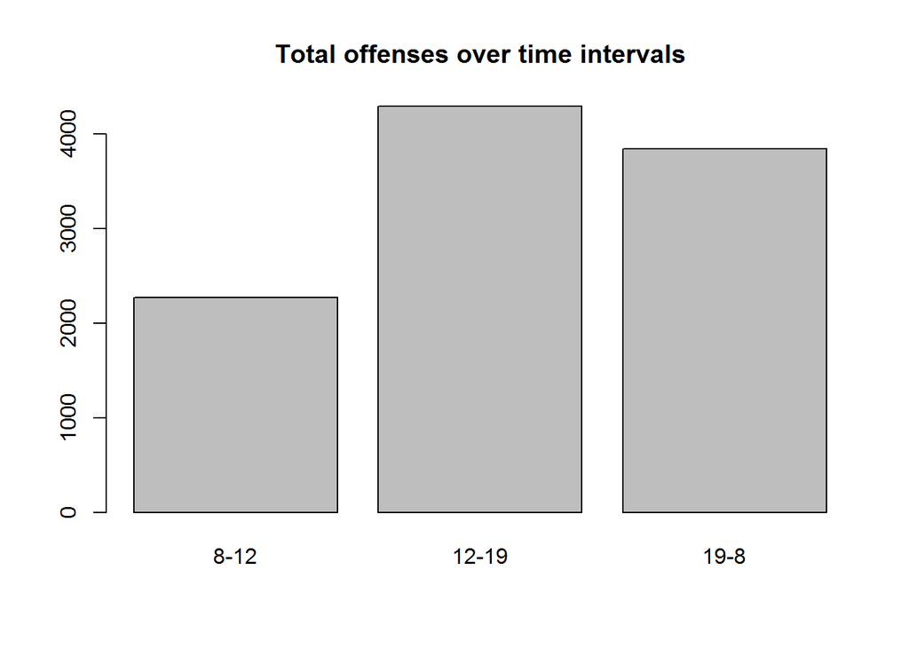

```r
barplot(c(sum(sum1$num), sum(sum2$num), sum(sum3$num)), names.arg = c("8-12", "12-19", "19-8"), main = "Total offenses over time intervals")
```

Number of occurences per year

```r
years <- sort(unique(sapply(strsplit(as.character(dat$Date),"-"), function(x) x[1])))
dates <- data.frame()

for(t in 1:length(years)) {
  y <- filter(dat, sapply(strsplit(as.character(dat$Date),"-"), function(x) x[1]) == years[t])
  total = sum(y$X..offenses)
  line <- data.frame(Year = years[t], Total = total)
  dates <- bind_rows(dates, line)
}
```

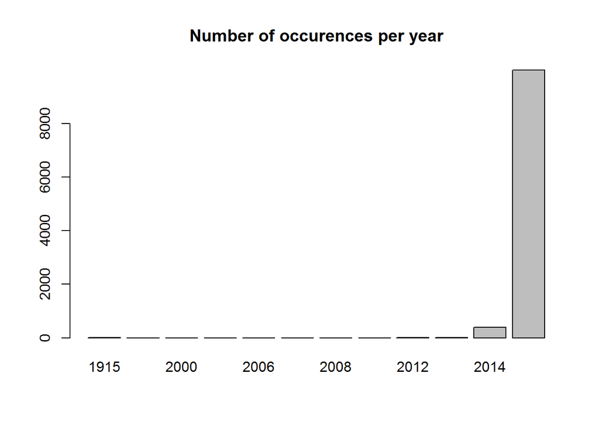

```r
barplot(dates$Total, names.arg=dates$Year, main="Number of occurences per year")
```

The six beats with more offenses:

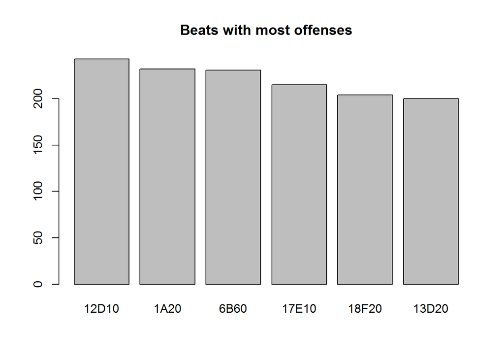

```r
beat <- group_by(dat, Beat) %>% summarise(num=sum(X..offenses))
most <- head(arrange(beat,desc(num)))
barplot(most$num, names.arg=most$Beat, main="Beats with most offenses")
```

The six beats with less offenses:

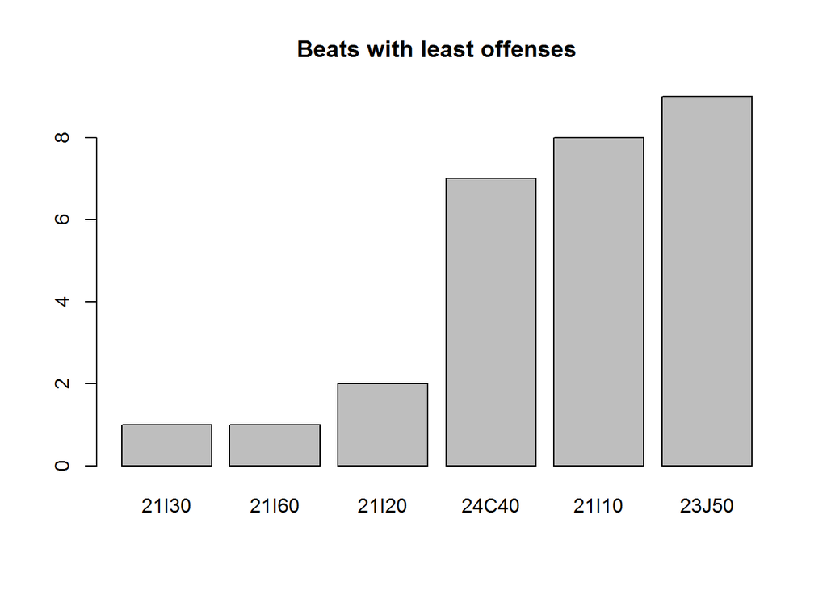

```r
least <- head(arrange(beat, num))
barplot(least$num, names.arg=least$Beat, main="Beats with least offenses")
```

Distribution of number of offenses per beat:

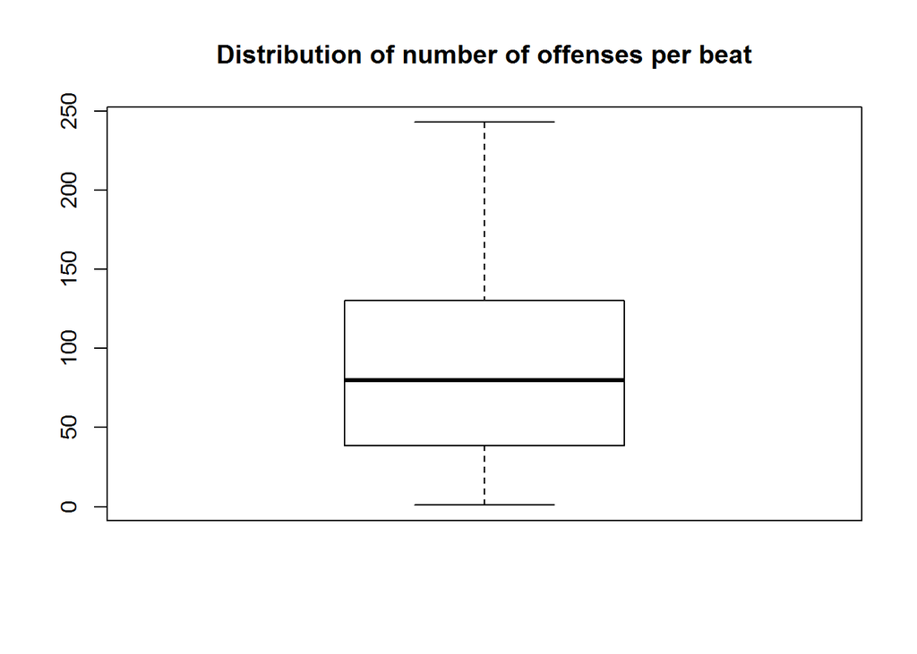

```r
boxplot(beat$num, main="Distribution of number of offenses per beat")
```

Number of occurrences per offense type:

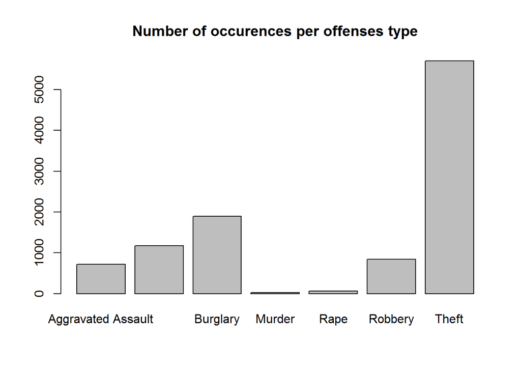

```r
offenses <- group_by(dat, Offense.Type) %>%
  filter(Offense.Type != 1) %>% summarize(total=sum(X..offenses))
barplot(offenses$total, names.arg=offenses$Offense.Type,
        main="Number of occurences per offenses type")
```

Distribution of number of offenses per beat:

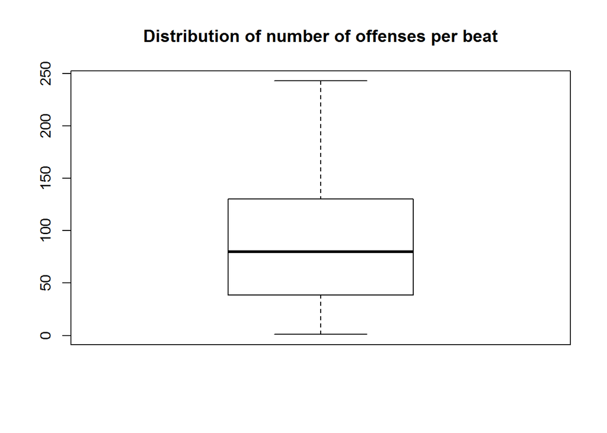

```r
boxplot(beat$num, main="Distribution of number of offenses per beat")
```

# Third Task

## Predictive modeling

We will try to obtain, using the available data, an approximation of the unknown function $(f)$ that maps the observation descriptors into the intended conclusion, i.e. $Prediction = f(Descriptors)$.

We take the `Beat` and `HourType` variables as descriptors, since we want to know the number of events/offenses in a beat and period day specifics. And we take as target variable the variable N of the data used for the prediction (`modelDat`) as it represents the number of events/offenses in a beat and period day specifics, since this variable is numerical we are faced with a regression problem.

The data in `modelDat` contains a selection of the data initially provided, but modified so that it can be used more easily in the predictive analysis.

### Prediction task

```r
fiscalDate <- function(arg) {
  date <- arg[2]
  hour <- arg[1]
  if (as.integer(hour) >= 0 && as.integer(hour) < 8)
    return(as.character(ymd(date)-1));
  return(as.character(ymd(date)));
}

#Identification of the time period
hourType <- function(hour) {
  hour <- as.integer(hour)
  if (8 <= hour && hour < 12)
    return(1)
  if (12 <= hour && hour < 19)
    return(2)
  return(3)
}

args <- mapply(c, dat$Hour, as.character(dat$Date), SIMPLIFY = FALSE)

dat <- mutate(dat, HourType=sapply(Hour, hourType))
dat <- mutate(dat, FiscalDate=sapply(args, fiscalDate))

modelDat <- group_by(dat, FiscalDate, Beat, HourType) %>% summarize(N=sum(X..offenses))
```

Our task is to get the best possible model, based on:

- the given data set;
- a certain preference criterion that allows comparing the different alternative model variants.

### Models

#### Holdout Method

```r
#Random data division
sp <- sample(1:nrow(modelDat), as.integer(nrow(modelDat)*0.7))
tr <- modelDat[sp,]
ts <- modelDat[-sp,]

#Neural Networks
(nn <- nnet(N ~ Beat + HourType, tr, size=8, decay=0.1, maxit=1000))
```

```
## a 115-8-1 network with 937 weights
## inputs: Beat10H20 Beat10H30 Beat10H40 Beat10H50 Beat10H60 Beat10H70 Beat10H80 Beat11H10 Beat11H20 Beat11H30 Beat11H40 Beat11H50 Beat12D10 Beat12D20 Beat12D30 Beat12D40 Beat12D50 Beat12D60 Beat12D70 Beat13D10 Beat13D20 Beat13D30 Beat13D40 Beat14D10 Beat14D20 Beat14D30 Beat14D40 Beat14D50 Beat15E10…
## output(s): N
## options were - decay=0.1
```

```r
preds <- predict(nn,ts)
mc <- table(preds,ts$N)

summary(nn)
```

```
## a 115-8-1 network with 937 weights
## options were - decay=0.1
##    b->h1   i1->h1   i2->h1   i3->h1   i4->h1   i5->h1   i6->h1   i7->h1
##     0.35     0.00     0.00     0.00     0.00     0.00     0.00     0.00
##   i8->h1   i9->h1  i10->h1  i11->h1  i12->h1  i13->h1  i14->h1  i15->h1
##     0.00     0.00     0.00     0.00     0.00     0.01     0.00     0.00
##  i16->h1  i17->h1  i18->h1  i19->h1  i20->h1  i21->h1  i22->h1  i23->h1
##     0.00     0.00     0.00     0.00     0.01     0.01     0.00     0.00
##  i24->h1  i25->h1  i26->h1  i27->h1  i28->h1  i29->h1  i30->h1  i31->h1
##     0.01     0.01     0.00     0.00     0.00     0.00     0.00     0.01
##  i32->h1  i33->h1  i34->h1  i35->h1  i36->h1  i37->h1  i38->h1  i39->h1
##     0.01     0.00     0.00     0.00     0.00     0.01     0.00     0.00
##  i40->h1  i41->h1  i42->h1  i43->h1  i44->h1  i45->h1  i46->h1  i47->h1
##     0.01     0.00     0.01     0.01     0.00     0.00     0.01     0.01
##  i48->h1  i49->h1  i50->h1  i51->h1  i52->h1  i53->h1  i54->h1  i55->h1
##     0.00     0.00     0.00     0.00     0.00     0.01     0.01     0.00
##  i56->h1  i57->h1  i58->h1  i59->h1  i60->h1  i61->h1  i62->h1  i63->h1
##     0.01     0.00     0.00     0.00     0.00     0.00     0.00     0.00
##  i64->h1  i65->h1  i66->h1  i67->h1  i68->h1  i69->h1  i70->h1  i71->h1
##     0.00     0.00     0.00     0.00     0.00     0.00     0.00     0.00
##  i72->h1  i73->h1  i74->h1  i75->h1  i76->h1  i77->h1  i78->h1  i79->h1
##     0.00     0.00     0.00     0.00     0.00     0.00     0.00     0.01
##  i80->h1  i81->h1  i82->h1  i83->h1  i84->h1  i85->h1  i86->h1  i87->h1
##     0.00     0.01     0.00     0.01     0.00     0.00     0.01     0.00
##  i88->h1  i89->h1  i90->h1  i91->h1  i92->h1  i93->h1  i94->h1  i95->h1
##     0.00     0.00     0.00     0.00     0.01     0.00     0.01     0.00
##  i96->h1  i97->h1  i98->h1  i99->h1 i100->h1 i101->h1 i102->h1 i103->h1
##     0.00     0.00     0.00     0.01     0.00     0.01     0.00     0.00
## i104->h1 i105->h1 i106->h1 i107->h1 i108->h1 i109->h1 i110->h1 i111->h1
##     0.00     0.00     0.00     0.00     0.00     0.00     0.00     0.00
## i112->h1 i113->h1 i114->h1 i115->h1
##     0.00     0.00     0.00     0.55
##    b->h2   i1->h2   i2->h2   i3->h2   i4->h2   i5->h2   i6->h2   i7->h2
##     0.35     0.00     0.00     0.00     0.00     0.00     0.00     0.00
##   i8->h2   i9->h2  i10->h2  i11->h2  i12->h2  i13->h2  i14->h2  i15->h2
##     0.00     0.00     0.00     0.00     0.00     0.01     0.00     0.00
##  i16->h2  i17->h2  i18->h2  i19->h2  i20->h2  i21->h2  i22->h2  i23->h2
##     0.00     0.00     0.00     0.00     0.01     0.01     0.00     0.00
##  i24->h2  i25->h2  i26->h2  i27->h2  i28->h2  i29->h2  i30->h2  i31->h2
##     0.01     0.01     0.00     0.00     0.00     0.00     0.00     0.01
```

[output cut: 189 more lines]

```
##     0.00     0.00     0.00     0.00     0.00     0.00     0.00     0.00
##  i72->h8  i73->h8  i74->h8  i75->h8  i76->h8  i77->h8  i78->h8  i79->h8
##     0.00     0.00     0.00     0.00     0.00     0.00     0.00     0.01
##  i80->h8  i81->h8  i82->h8  i83->h8  i84->h8  i85->h8  i86->h8  i87->h8
##     0.00     0.01     0.00     0.01     0.00     0.00     0.00     0.00
##  i88->h8  i89->h8  i90->h8  i91->h8  i92->h8  i93->h8  i94->h8  i95->h8
##     0.00     0.00     0.00     0.00     0.01     0.00     0.01     0.00
##  i96->h8  i97->h8  i98->h8  i99->h8 i100->h8 i101->h8 i102->h8 i103->h8
##     0.00     0.00     0.00     0.01     0.00     0.01     0.00     0.00
## i104->h8 i105->h8 i106->h8 i107->h8 i108->h8 i109->h8 i110->h8 i111->h8
##     0.00     0.00     0.00     0.00     0.00     0.00     0.00     0.00
## i112->h8 i113->h8 i114->h8 i115->h8
##     0.00     0.00     0.00     0.55
##  b->o h1->o h2->o h3->o h4->o h5->o h6->o h7->o h8->o
##  1.63  1.28  1.28  1.28  1.28  1.29  1.28  1.28  1.28
```

```r
(error <- 100*(1-sum(diag(mc))/sum(mc)))
```

```
## [1] 99.88707
```

```r
regr.eval(ts$N, preds)
```

```
##       mae       mse      rmse      mape
## 0.7730704 1.8120448 1.3461221 0.2670085
```

```r
#SVMs
(s <- svm(N ~ Beat + HourType,tr))
```

```
##
## Call:
## svm(formula = N ~ Beat + HourType, data = tr)
##
##
## Parameters:
##    SVM-Type:  eps-regression
##  SVM-Kernel:  radial
##        cost:  1
##       gamma:  0.00862069
##     epsilon:  0.1
##
##
## Number of Support Vectors:  3682
```

```r
preds <- predict(s,ts)
mc <- table(preds,ts$N)

summary(s)
```

```
##
## Call:
## svm(formula = N ~ Beat + HourType, data = tr)
##
##
## Parameters:
##    SVM-Type:  eps-regression
##  SVM-Kernel:  radial
##        cost:  1
##       gamma:  0.00862069
##     epsilon:  0.1
##
##
## Number of Support Vectors:  3682
```

```r
(error <- 100*(1-sum(diag(mc))/sum(mc)))
```

```
## [1] 99.77414
```

```r
regr.eval(ts$N, preds)
```

```
##       mae       mse      rmse      mape
## 0.7534673 1.4293714 1.1955632 0.3245764
```

```r
#MARS
mars <- earth(N ~ Beat + HourType, tr)
preds <- predict(mars,ts)
mc <- table(preds,ts$N)

summary(mars)
```

```
## Call: earth(formula=N~Beat+HourType, data=tr)
##
##               coefficients
## (Intercept)      1.6326069
## Beat11H10        0.5131844
## Beat12D10        1.3381521
## Beat13D20        1.0555846
## Beat14D20        0.5660464
## Beat15E20       -0.3924603
## Beat15E40        0.5381676
## Beat17E10        1.0431271
## Beat17E40        0.3365934
## Beat18F20        0.9563744
## Beat18F30        0.3281792
## Beat18F40        0.5664204
## Beat19G10        0.7843716
## Beat1A10         0.3808300
## Beat1A20         0.9689644
## Beat1A30         0.9514729
## Beat1A50         0.6847760
## Beat20G30        0.4870001
## Beat20G50        0.4938700
## Beat24C50       -0.4859226
## Beat2A50         0.4945577
## Beat2A60         0.3552107
## Beat3B10         0.8868095
## Beat3B50         0.4842818
## Beat5F30         0.7186743
## Beat6B10         0.7126981
## Beat6B50         0.4465177
## Beat6B60         0.9996322
## Beat7C20         0.4660962
## Beat9C40         0.4129910
## h(2-HourType)   -0.3956233
##
## Selected 31 of 32 terms, and 30 of 115 predictors
## Termination condition: RSq changed by less than 0.001 at 32 terms
## Importance: HourType, Beat12D10, Beat13D20, Beat17E10, Beat1A20, ...
## Number of terms at each degree of interaction: 1 30 (additive model)
## GCV 1.115049    RSS 4470.119    GRSq 0.1077937    RSq 0.1335353
```

```r
(error <- 100*(1-sum(diag(mc))/sum(mc)))
```

```
## [1] 99.66121
```

```r
regr.eval(ts$N, preds)
```

```
##       mae       mse      rmse      mape
## 0.7822833 1.0670968 1.0330038 0.4983028
```

```r
#Tree-based
rpart <- rpartXse(N ~ Beat + HourType,tr)
preds <- predict(rpart,ts)
mc <- table(preds, ts$N)

summary(rpart)
```

```
## Call:
## rpart(formula = form, data = data, cp = cp, minsplit = minsplit)
##   n= 4130
##
##           CP nsplit rel error   xerror       xstd
## 1 0.08709133      0 1.0000000 1.000427 0.04111928
## 2 0.02379940      1 0.9129087 0.933947 0.03723925
## 3 0.02102293      2 0.8891093 0.910529 0.03597210
##
## Variable importance
##     Beat HourType
##       79       21
##
## Node number 1: 4130 observations,    complexity param=0.08709133
##   mean=1.761985, MSE=1.24916
##   left son=2 (2898 obs) right son=3 (1232 obs)
##   Primary splits:
##       Beat     splits as  LLLLLLLLRLLLLRLLLLLLLRLLLRLLLLLLRLLLLRLLLLRLRLLRLLLLLRRLRLLRLRLLLLLLLLLLLLLLLLLLLRLRLLRLLLLLRLRLLLRRLRLLLLLLLLLLLLR, improve=0.08709133, (0 missing)
##       HourType < 1.5 to the left,  improve=0.02257116, (0 missing)
##
## Node number 2: 2898 observations
##   mean=1.546929, MSE=0.7619454
##
## Node number 3: 1232 observations,    complexity param=0.0237994
##   mean=2.267857, MSE=2.030525
##   left son=6 (338 obs) right son=7 (894 obs)
##   Primary splits:
##       HourType < 1.5 to the left,  improve=0.04908119, (0 missing)
##       Beat     splits as  --------L----R-------R---L------L----R----R-L--L-----RR-L--L-L-------------------L-R--L-----L-L---LR-L------------L, improve=0.02551382, (0 missing)
##
## Node number 6: 338 observations
##   mean=1.754438, MSE=1.019581
##
## Node number 7: 894 observations
##   mean=2.461969, MSE=2.275399
```

```r
(error <- 100*(1-sum(diag(mc))/sum(mc)))
```

```
## [1] 51.43986
```

```r
regr.eval(ts$N, preds)
```

```
##       mae       mse      rmse      mape
## 0.8133437 1.0774617 1.0380085 0.5215996
```

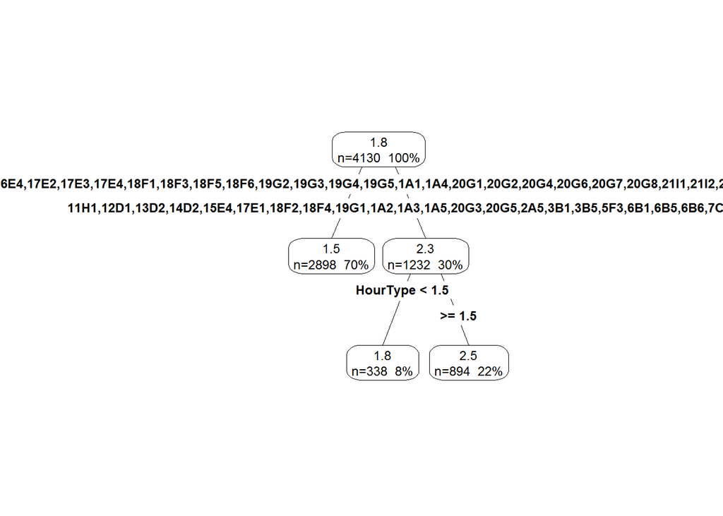

```r
##Plot of the decision tree
prp(rpart, type=4,extra=101)
```

#### Bootstrap Method and Performance estimatio

We can collect a series of scores and provide the average of these scores as our estimate, along with the standard error of this estimate, repeating the tests 10 times. To do that, we will use the Bootstrap method.

```r
nreps <- 10
scores <- list(nnet=vector("numeric",length=nreps),
               svm=vector("numeric",length=nreps),
               earth=vector("numeric",length=nreps),
               rpartXse=vector("numeric",length=nreps))

n <- nrow(modelDat)
set.seed(1234)
for(i in 1:nreps) {
   # random sample with replacement
   sp <- sample(n,n,replace=TRUE)
   # data splitting
   tr <- modelDat[sp,]
   ts <- modelDat[-sp,]

   # model learning and prediction
   m <- nnet(N ~ Beat + HourType,tr, size=8, decay=0.1, maxit=1000)
   p <- predict(m,ts)
   # evaluation
   scores$nnet[i] <- mean((ts$N-p)^2)

   m <- svm(N ~ Beat + HourType,tr)
   p <- predict(m,ts)
   scores$svm[i] <- mean((ts$N-p)^2)

   m <- earth(N ~ Beat + HourType,tr)
   p <- predict(m,ts)
   scores$earth[i] <- mean(abs(ts$N-p)^2)

   m <- rpartXse(N ~ Beat + HourType,tr)
   p <- predict(m,ts)
   scores$rpartXse[i] <- mean((ts$N-p)^2)
}
# calculating means and standard errors
summary(scores$nnet)
```

```
##    Min. 1st Qu.  Median    Mean 3rd Qu.    Max.
##   1.700   1.793   1.807   1.813   1.847   1.930
```

```r
summary(scores$svm)
```

```
##    Min. 1st Qu.  Median    Mean 3rd Qu.    Max.
##   1.208   1.333   1.351   1.348   1.374   1.461
```

```r
summary(scores$earth)
```

```
##    Min. 1st Qu.  Median    Mean 3rd Qu.    Max.
##   1.065   1.084   1.094   1.099   1.121   1.137
```

```r
summary(scores$rpartXse)
```

```
##    Min. 1st Qu.  Median    Mean 3rd Qu.    Max.
##   1.066   1.087   1.100   1.101   1.111   1.148
```

```r
#performanceEstimation to estimate regression error
res <- performanceEstimation(PredTask(N ~ Beat + HourType, modelDat, "w/o"), workflowVariants(learner=c("svm", "earth", "rpartXse")), EstimationTask(metrics = c("mse", "mae")))
```

```
##
##
## ##### PERFORMANCE ESTIMATION USING  CROSS VALIDATION  #####
##
## ** PREDICTIVE TASK :: w/o
##
## ++ MODEL/WORKFLOW :: svm
## Task for estimating  mse,mae  using
##  1 x 10 - Fold Cross Validation
##   Run with seed =  1234
## Iteration :**********
##
##
## ++ MODEL/WORKFLOW :: earth
## Task for estimating  mse,mae  using
##  1 x 10 - Fold Cross Validation
##   Run with seed =  1234
## Iteration :**********
##
##
## ++ MODEL/WORKFLOW :: rpartXse
## Task for estimating  mse,mae  using
##  1 x 10 - Fold Cross Validation
##   Run with seed =  1234
## Iteration :**********
```

```r
summary(res)
```

```
##
## == Summary of a  Cross Validation Performance Estimation Experiment ==
##
## Task for estimating  mse,mae  using
##  1 x 10 - Fold Cross Validation
##   Run with seed =  1234
##
## * Predictive Tasks ::  w/o
## * Workflows  ::  svm, earth, rpartXse
##
## -> Task:  w/o
##   *Workflow: svm
##               mse        mae
## avg     1.3754573 0.74341508
## std     0.1758209 0.04151945
## med     1.3191339 0.73417128
## iqr     0.2617591 0.05695091
## min     1.1716352 0.69881691
## max     1.6873333 0.82801718
## invalid 0.0000000 0.00000000
##
##   *Workflow: earth
##               mse        mae
## avg     1.0982214 0.79057619
## std     0.1126196 0.02944775
## med     1.0536013 0.78512011
## iqr     0.1370579 0.04085984
## min     0.9497573 0.75041971
## max     1.2984281 0.84680740
## invalid 0.0000000 0.00000000
##
##   *Workflow: rpartXse
##               mse        mae
## avg     1.1246942 0.81687858
## std     0.1193669 0.02616683
## med     1.0742092 0.80973368
## iqr     0.1416450 0.02335126
## min     0.9770696 0.78522869
## max     1.3226988 0.86618968
## invalid 0.0000000 0.00000000
```

```r
rankWorkflows(res,3)
```

```
## $`w/o`
## $`w/o`$mse
##   Workflow Estimate
## 1    earth 1.098221
## 2 rpartXse 1.124694
## 3      svm 1.375457
##
## $`w/o`$mae
##   Workflow  Estimate
## 1      svm 0.7434151
## 2    earth 0.7905762
## 3 rpartXse 0.8168786
```

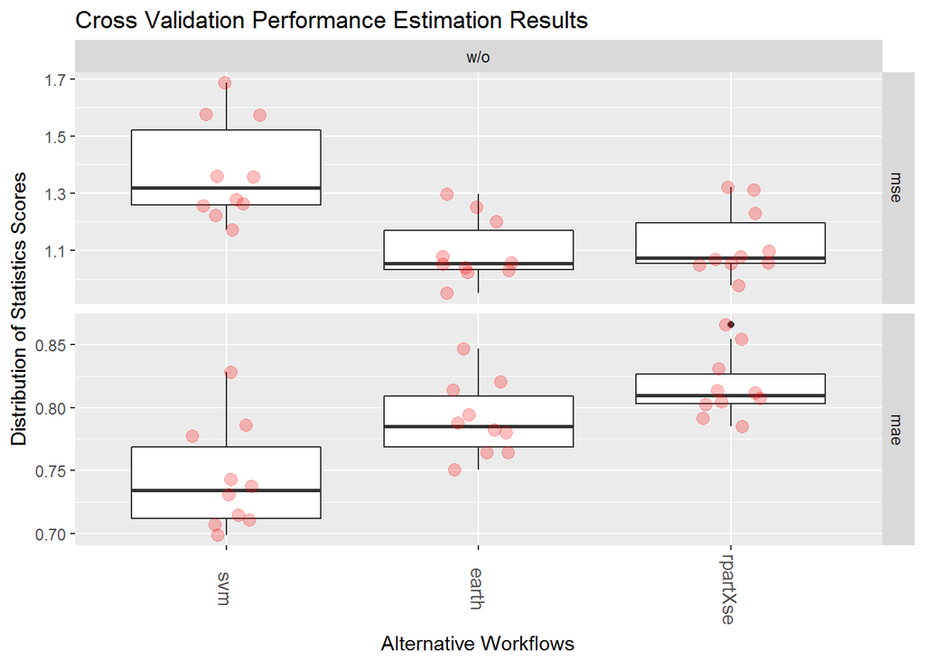

```r
plot(res)
```

### Justification

As we can see, our predictive analysis involved the analysis of four predictive models, one based on neural networks (`nnet`), one on Support Vector Machines (`svm`), another on Multivariate Adaptive Regression Splines (`earth`) and other tree-based (`rpartXse`).

Initially we performed a test involving the Holdout method that consists on randomly dividing the available data sample in two sub-sets, one used for training the model and the other for testing/evaluating it. The used proportion for training was 70% and for testing was 30%.

In a second phase, we performed a test involving the Bootstrap method that consists of training models on a random sample with replacement from the original data set and test multiple times the models on the cases that were not used on the training set and calculate the average of the scores on these repetitions (Bootstrap estimate). We checked the summary of the different results obtained with the help of the `performanceEstimation` function that performs comparative experiments of the different models, we obtain a plot with cross validation performance estimation results.

Multivariate Adaptive Regression Splines, also known as MARS, is a model that takes the form of an expansion in product spline basis functions, where the number of basic functions as well as the parameters associated with each one are automatically determined by the data. MARS builds models in two phases: the forward and backward passes and has more power and flexibility to model relationships that are nearly additive or involve interactions in at most a few variables.

Tree based models are one of the best and most used learning methods. They empower predictive models with high accuracy, stability and ease of interpretation. Tree based models are also adaptable at solving any kind of problem at hand (classification or regression), so it’s not a surprise that good results were obtained.